# BRIDGE

[figure not shown]

BRIDGE-ing Generations, Competencies, and Transitions in the Digital Transformation of Higher Education

PD Dr. Sandra Grinschgl

Psychology of Digitalization

Prof. Dr. Michael Schulte-Mecklenbeck

Decision Science & Behavior Change

University of Bern

Do you know  
your partner's phone number  
by heart?

## A tension

↑

Task performance

when we offload  
to a device

↓

Memory formation

Up- and deskilling at the same time, in the same person.

Grinschgl et al. (2021)

What if we offload academic competencies like  
critical thinking, writing, reasoning, data literacy, and deciding  
to AI?

## Better homework, worse exams

Without AIAfter starting to use AI

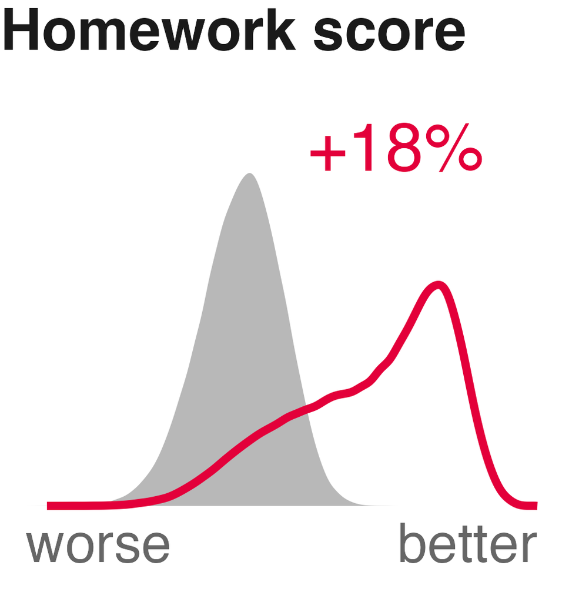

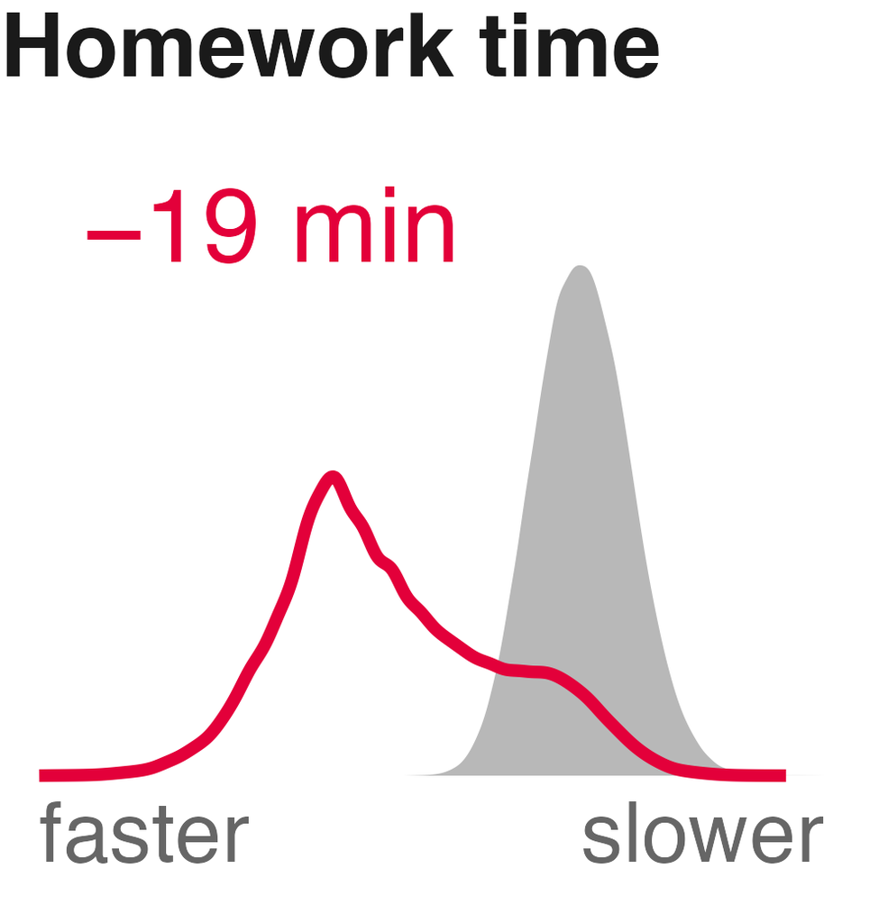

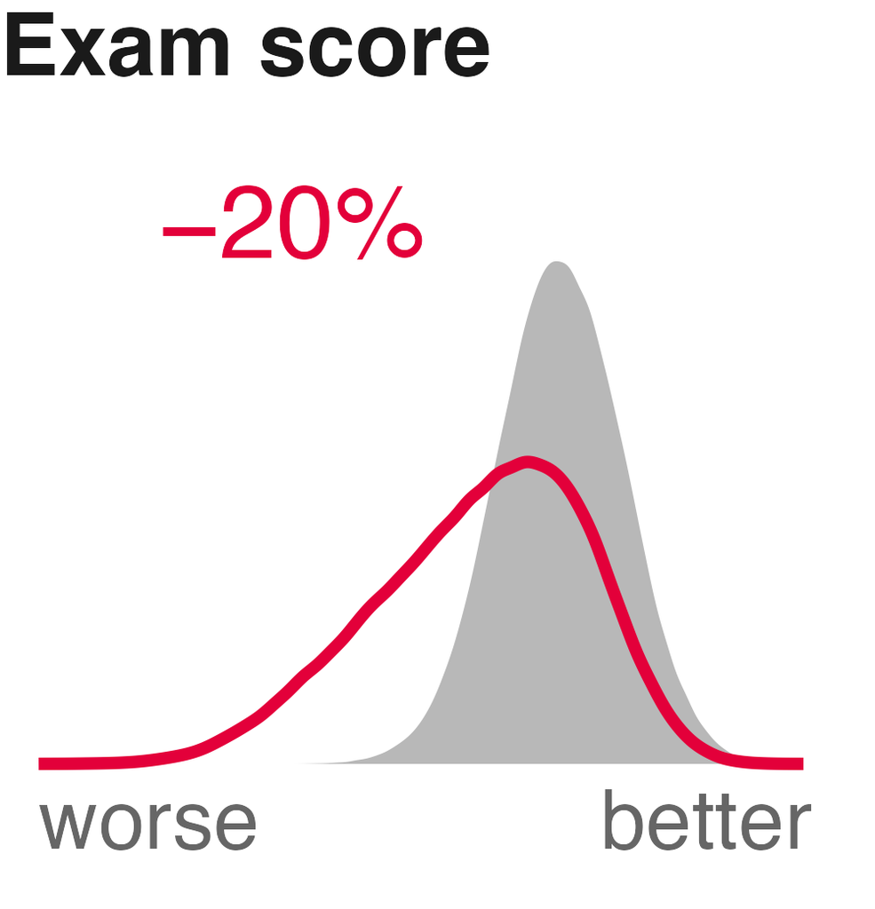

Tension within each student

Strömberg et al. (2026)

88%of students use generative AI  
for learning

29%believe that their lecturers are equipped to guide them on AI use

Tension between university groups

Digital Education Council (2026)

## Why now

1Tensions are assumed, not measured

"Fluent students, unprepared staff."

Self-report snapshots,  
no performance data,  
no comparison.

2Tensions move every year

Students bring new tools and habits; staff can only adapt at institutional speed.

No longitudinal evidence.

3AI happens now

Rules about teaching, research, and administration are written before the evidence exists.

Swiss Science Council (2026): "Evidence urgently needed."

A university that does not know its students and staff works past them.

Swiss Science Council & Seufert (2026)

[figure not shown]

Bridging generations, competencies, and transitions  
in the digital transformation at UniBE

## The preparatory project

4facultiesHuman Sciences, Business & Economics, Medicine, Humanities

7central unitsLEAD, KILOF, Data Science Lab, VR Teaching, Administrative Director's Office, Lifelong Learning Center, UniBE-IT

2external partnersBeLEARN, PHBern

1Community of Practice

1. Recruiting CoP members
2. 1st CoP meeting
3. Literature review
4. 2nd CoP meeting
5. BRIDGE model
6. White-paper writing
7. UniBE-wide survey
8. Core-team retreat
9. White paper
10. Grant, Sep 2026

Support letters:

[figure not shown]

Student body

[figure not shown]

University Library

[figure not shown]

Beratungsstelle der Berner Hochschulen

[figure not shown]

Teaching Support Center

[figure not shown]

**Maturitätskommission**

## The BRIDGE model

Digitalization

School

University

Labor market

University members

[figure not shown]

Students

[figure not shown]

Academic staff

[figure not shown]

Support staff

Competencies

- Psycho-social
- Health & well-being
- Performance

Outcomes

- Academic achievement
- Institutional effectiveness
- Career transition

## Three cross-cutting tensions

Individualization  
vs. collaboration

Does an AI tutor replace the exchange with peers?

Psycho-social  
competencies

Autonomy  
vs. dependence

When does digital support relieve load, and when does it create technostress?

Health &  
well-being

Upskilling  
vs. deskilling

How large is the mismatch between self-assessed and measured AI competence?

Performance  
competencies

How do these tensions **develop** (for whom and under what conditions)?  
What shifts them toward beneficial outcomes?

## The interdisciplinary team

Human Sciences

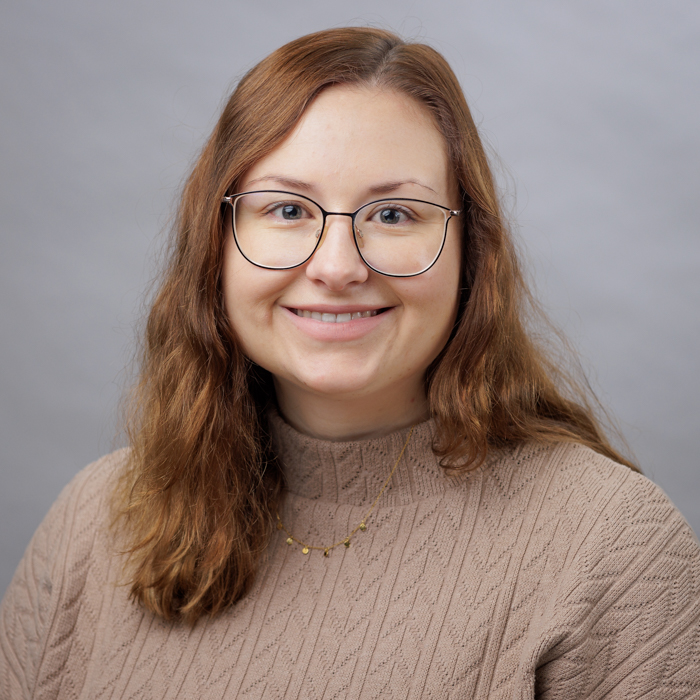

**Grinschgl**Psychology: Offloading, competence judgments

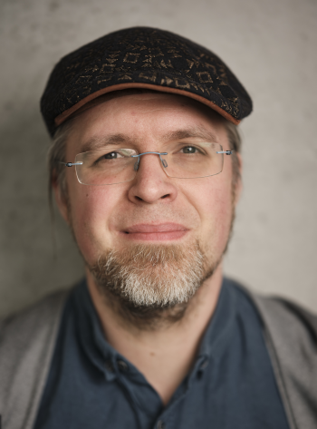

**Elson**Measurement, open science, data privacy

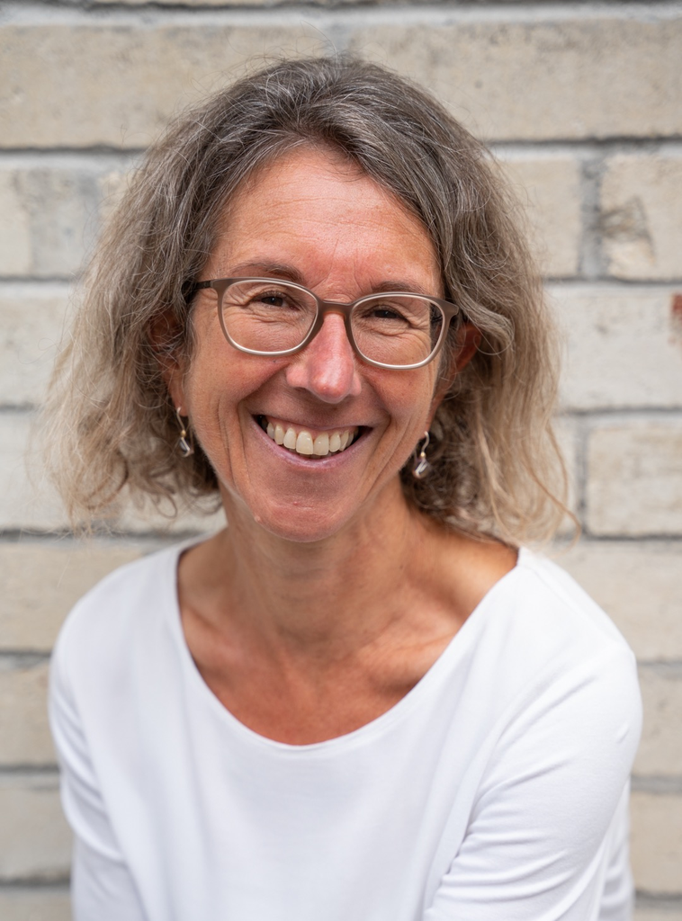

**Hascher**Well-being in education

Business & Economics

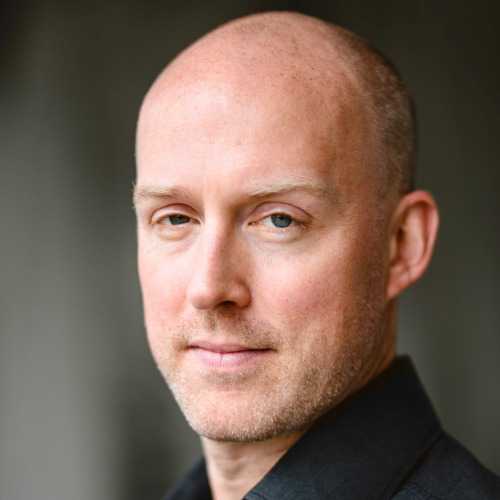

**Schulte-Mecklenbeck**Decision science: Behavior change, trials

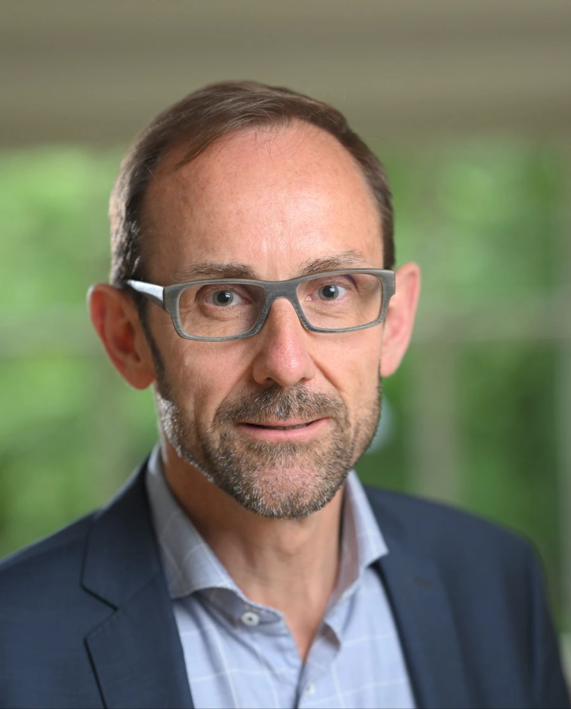

**Ritz**Public management

Medicine

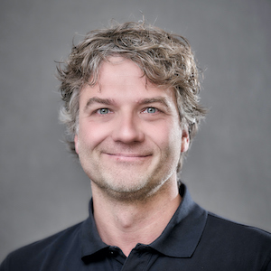

**Sauter**Emergency medicine: Digital decision tools

## Tina Hascher

Tina  
Hascher

Well-being in education

Human Sciences

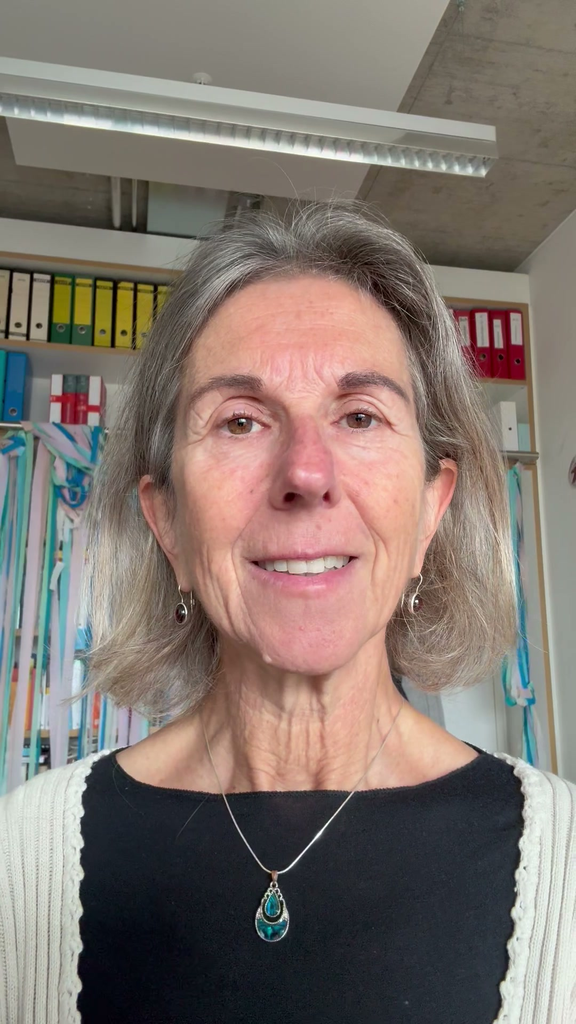

## The interdisciplinary team

Human Sciences

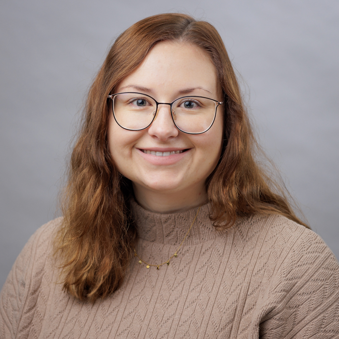

**Grinschgl**Psychology: Offloading, competence judgments

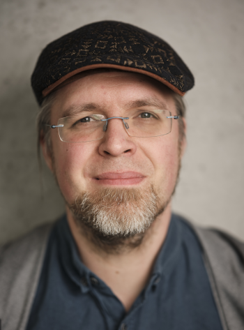

**Elson**Measurement, open science, data privacy

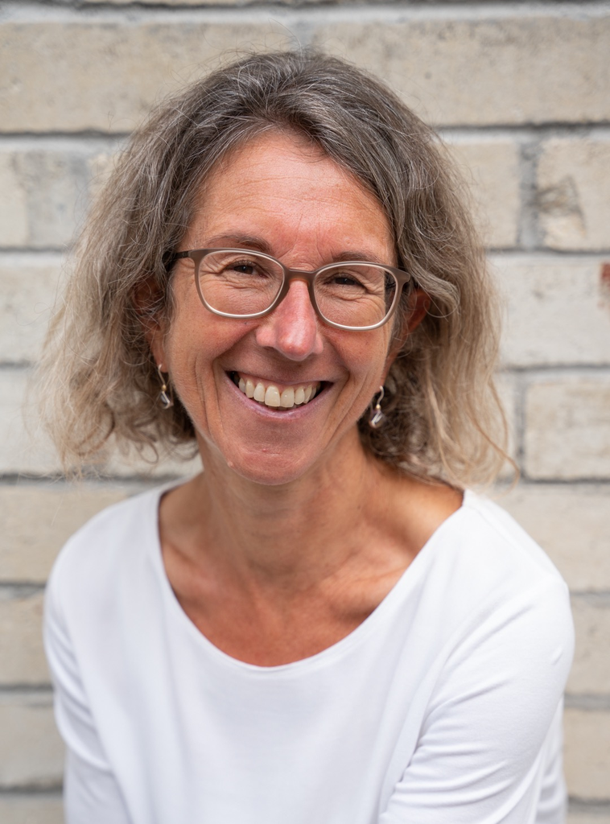

**Hascher**Well-being in education

Business & Economics

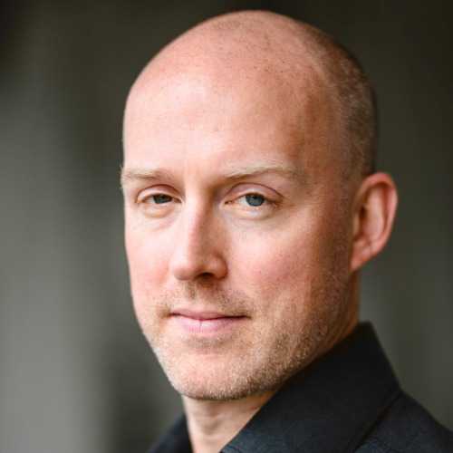

**Schulte-Mecklenbeck**Decision science: Behavior change, trials

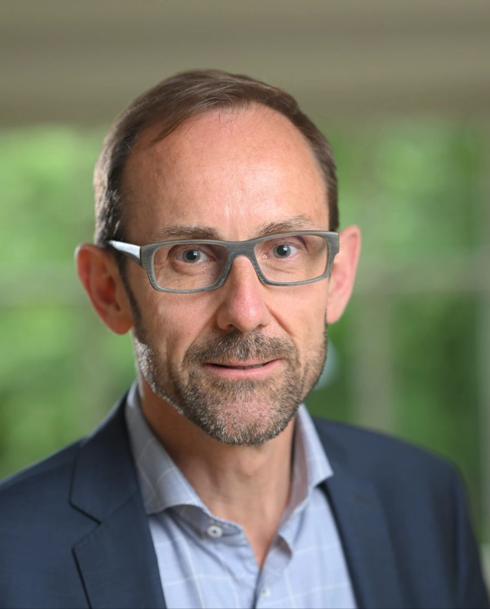

**Ritz**Public management

Medicine

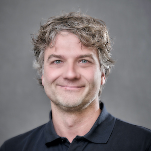

**Sauter**Emergency medicine: Digital decision tools

Each tension needs an expert to **identify and transform** it; the institution needs one that studies **organizations**, the high-stakes case needs **clinicians**.

## Thomas Sauter

Thomas  
Sauter

Emergency medicine:  
Digital decision tools

Medicine

[figure not shown]

## How BRIDGE works

1. 1**One panel**

   5,200 UniBE members: **Students, academic & support staff**, four waves **2027–2030**
2. 2**Identify**

   **what is happening:** Where groups & expectations differ, how digitalization changes processes  
   **years 1–4**
3. 3**Transform**

   **what helps:**  
   Co-designed interventions, randomized trials, field studies with follow-up  
   **years 2–4**
4. 4**Implement**

   **at UniBE:** One research unit runs the panel and turns results into practice

Every step uses the same people: baseline, recruitment pool, follow-up.

## Multi-group panel

**Fixed core:** Validated scales + performance tasks → compare groups & years

1. **Wave 1** (2027)
2. **Wave 2** (2028)
3. **Wave 3** (2029)
4. **Wave 4** (2030)

**+ Rotating module:** Current tools & practices, open-call, new every wave

**+ Sub-samples:** Interventions, experience sampling, open-call

**Attrition**: Oversampling and refreshment samples to offset 20% attrition per year, ~25 min once a year, feedback reports, institutional embedding

## Tailored intervention design

[figure not shown]

## Malte Elson

Malte  
Elson

Measurement, open science,  
data privacy

Human Sciences

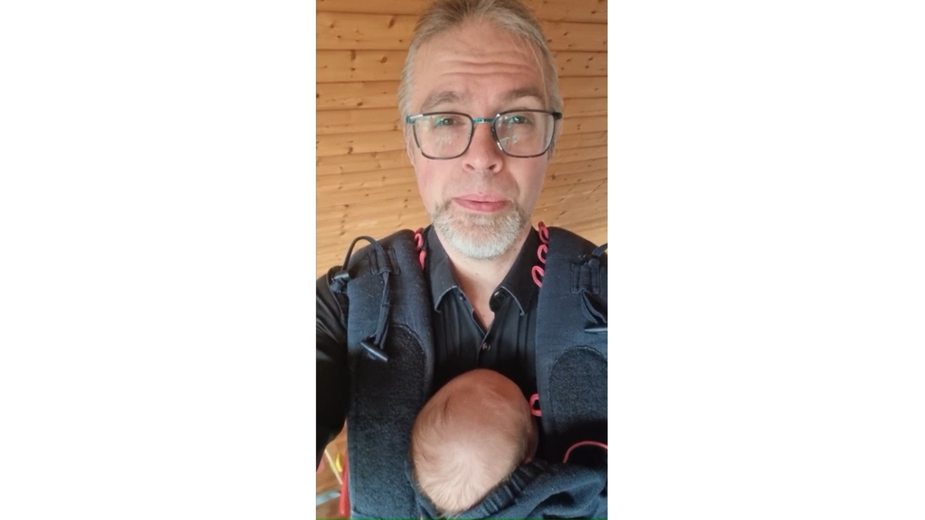

## What BRIDGE delivers

2027–2030: we build

Evidence and a unit that acts on it

Identification: Tensions within and between groups

Transformation: Tailored educational strategies & processes

Digitalization Strategy 2030, Fit for Future, Sustainability

## Adrian Ritz

Adrian  
Ritz

Public management

Business & Economics

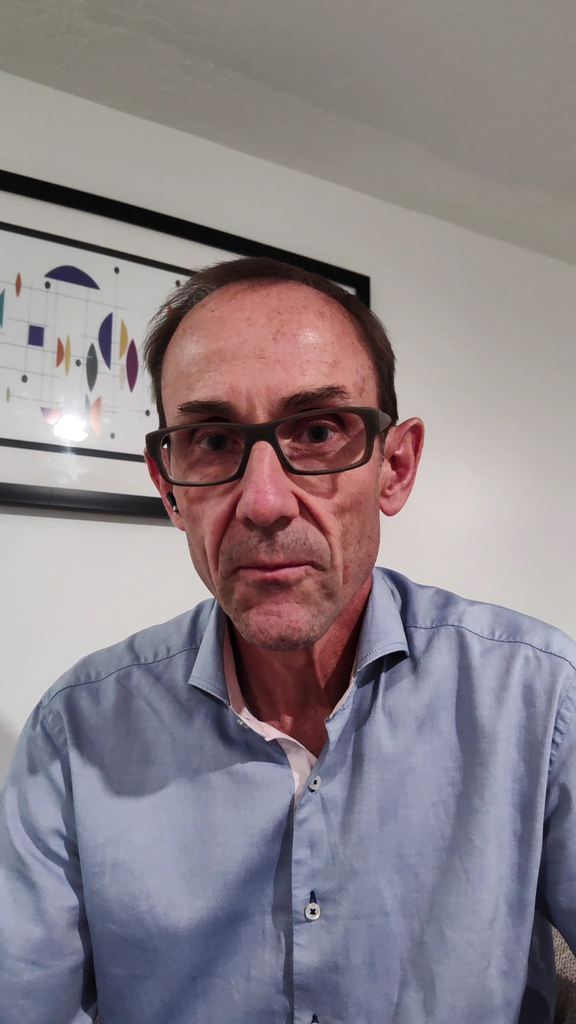

## What BRIDGE delivers

2027–2030: we build

Evidence and a unit that acts on it

Identification: Tensions within and between groups

Transformation: Tailored educational strategies & processes

Digitalization Strategy 2030, Fit for Future, Sustainability

After 2030: we continue

What stays

The evidence & panel as open infrastructure

National (Swiss Science Council, swissuniversities) & international priorities (EU, OECD):  
ERC Synergy, NCCR, Horizon Europe

## Why BRIDGE, why now

[figure not shown]

**Unique**3 groups, over time, within one institution: UniBE will be first!

**Urgent**AI has arrived. Tensions will grow within and between groups.

**Lasting**An open panel, new evidence, and follow-up funding.

Everyone calls this evidence essential. Nobody has it.

BRIDGE is ready to deliver.

[figure not shown]

Questions?

Model, white paper, and survey results:  
www.bridge-network.ch

[figure not shown]

## Why BRIDGE, why now

[figure not shown]

**Unique**3 groups, over time, within one institution: UniBE will be first!

**Urgent**AI has arrived. Tensions will grow within and between groups.

**Lasting**An open panel, new evidence, and follow-up funding.

[figure not shown]

Students

[figure not shown]

Academic  
staff

[figure not shown]

Support  
staff